# OBLIG1Sok2009_36

### Obligatorisk oppgave SOK-2009

#### Kanditat: 36

#### Oppgave 1

*En diskret variabel X kan ta verdiene $ x_i $ ∈ $\{ x_0.....x_N \}$. Forventningen til $ X, E[X] $, er summen av mulige utfall ganger sannsynligheten for utfallet:*

$ E[X] = x_0p(x_0) + x_1p(x_2) + ...... + x_Np(x_n) $

*Bruk definisjon til å finne forventingen av en variabel T som er lik antall prikker på en seks-sidet terning t ∈ $ \{1...6\} $ der alle utfall har samme sannsynlighet $ p(X=x) = \dfrac{1}{6}$. Vi skriver dette, E[T]. Hva er sannsynligheten for å få den forventende veriden? Forklar svaret ditt?*

$ E(T) = 1 * \dfrac{1}{6} + 2 * \dfrac{1}{6} + 3 * \dfrac{1}{6} + 4 * \dfrac{1}{6} + 5 * \dfrac{1}{6} + 6 * \dfrac{1}{6} = 3,5 $

Forventningsverdien til terningen $ E[T] = 3,5 $

$ p(t = 3,5) = 0 $

Ingen utfall på terningen har 3,5 prikker. Forventningen er et teoretisk gjennomsnitt, det vil si at at dersom man gjentok forsøket i det uendelige vil forventet verdi (gjennomsnittet) tendere mot 3.5.

#### Oppgave 2

*Finn forventingen til summen av to seksidede terninger $ 2T,E[2T] $. Hva er forskjellen mellom sannsynligheten $ p(2T = t) $ og $ p(T=t) $?*

$ E[2T] = {\sum }^{12}_{t=2}p(2T = t)t $ = $ 2 * \dfrac{1}{36} + 3 * \dfrac{2}{36} + 4 * \dfrac{3}{36} + 5 * \dfrac{4}{36} .... + 12 *\dfrac{1}{36} = 7 $

Forventningsverdien til 2 terninger $ E[2T] = 7 $

Fordelingen er den viktigste forskjellen mellom de to sannsynlighetene. T er en diskret uniform fordeling. En uniform sannsynlighet betyr at alle utfallene er like sannsynlige. 2T er også en diskret sannsynlighetsfordeling, men den er ikke uniform. Det betyr at ikke alle utfallene er like sannsynlige. For 2T er sannsynligheten for syv prikker større enn sannsynligheten for to prikker, da seks utfall gir syv prikker mens kun et utfall gir to prikker.

For egen skyld har jeg laget en funksjon for 2 terninger og kastet den 100 000 ganger. Observerer en fordeling rundt forventningsverdien 7.

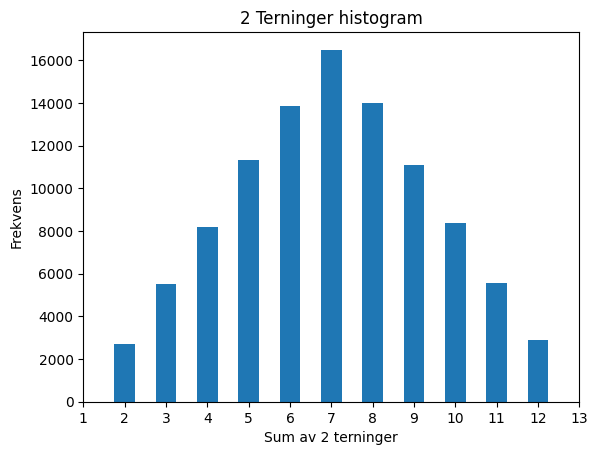

#### Oppgave 3

*Hva er utfallsrommet for 2T og for antall prikker på to separate terninger T,T?*

For 2T er det 36 mulige utfall. Utfallsrommet for 2T:

|  | **1** | **2** | **3** | **4** | **5** | **6** |
| --- | --- | --- | --- | --- | --- | --- |
| **1** | 2 | 3 | 4 | 5 | 6 | 7 |
| **2** | 3 | 4 | 5 | 6 | 7 | 8 |
| **3** | 4 | 5 | 6 | 7 | 8 | 9 |
| **4** | 5 | 6 | 7 | 8 | 9 | 10 |
| **5** | 6 | 7 | 8 | 9 | 10 | 11 |
| **6** | 7 | 8 | 9 | 10 | 11 | 12 |

Dersom vi ser på terningene helt separate terninger er det seks mulige utfall på hver enkelt terning.

Utfallsrommet for to terninger uten å legge sammen: t,t $ = \{1,2,3,5,6\} $

#### Oppgave 4

*En sannsynlighetsfordeling for en diskret variabel som T gir sannsynligheten for å få de mulige verdiene i utfallsrommet:*

$ f(x) = P(X = x) $

*Den kumulative sannsynlighetsfordelingen gir sannsynligheten for at en variabel skal være mindre eller lik en gitt verdi x:*

$ F(x) = P(X ≤ x) $

*Hva er $ f(5) $ for en eller to terninger? Hva er $ f(3) $ for en eller to terninger?*

For en terning t:

$ f(3) = P(x ≤ 3) = P(x = 1) + P(x = 2) + P(x = 3) = \dfrac{1}{6} + \dfrac{1}{6} + \dfrac{1}{6} = \dfrac{3}{6} = \dfrac{1}{2} $

$ f(5) = P(x ≤ 5) = P(x = 1) + P(x = 2) .... + P(x = 5)= \dfrac{1}{6} + \dfrac{1}{6} + \dfrac{1}{6} + \dfrac{1}{6} + \dfrac{1}{6} = \dfrac{5}{6} $

For 2 terninger 2T:

$ f(3) = P(x ≤ 3) = P(x = 2) + P(x = 3) = \dfrac{1}{36} + \dfrac{2}{36} = \dfrac{3}{36} $

$ f(3) = P(x ≤ 5) = P(x = 1) + P(x = 2) + P(x = 3) + P(x = 4) + P(x = 5) = \dfrac{1}{36} + \dfrac{2}{36} + \dfrac{3}{36} + \dfrac{4}{36} = \dfrac{1+2+3+4}{36} = \dfrac{5}{18} $

#### Oppgave 5

*Anta at en terning har N > 3 sider med* $\{1, 2, 3..t..,(N − 1), N \} $ *prikker på hver side. Hva er sannsynligheten for å få t prikker? Kan du skrive et uttrykk for forventet antall prikker?*

$ P(t) = \dfrac{\text{antall måter å få t på}}{\text{totalt antall utfall}} $.

Kaller antall måter å få t på = $ nt $

Sannsynligheten for å få antall t prikker = $ P(t) = \dfrac{nt}{N} $

For å finne forventningen $ E[t] $, bruker jeg $ \dfrac{1}{N} $.

$ E[t] = {\sum}^{N}_{i=1} i * \dfrac{1}{N} $

#### Oppgave 6

*Kan du finne sannsynligheten for at antall prikker på 2 terninger ligger over 2 eller under 12, det vil si $ P(3 ≤ 2T ≤ 11) = F(11) − F(3) $*

$ P(T_2 < 12) = P(T_2 = 11) + P(T_2 = 10) .... + P(T_2 = 2) = \dfrac{2}{36} + \dfrac{3}{36} + \dfrac{4}{36} + \dfrac{5}{36} + \dfrac{6}{36} + \dfrac{5}{36} + \dfrac{4}{36} + \dfrac{3}{36} + \dfrac{2}{36} + \dfrac{1}{36} = \dfrac{35}{36} $

$ P(T_2 < 3) = P(T_2 = 2) = \dfrac{1}{36} = \dfrac{1}{36} $

$ P(3 ≤ 2T ≤ 11) = \dfrac{35}{36} - \dfrac{1}{36} = \dfrac{34}{36} $

Sannsynligheten for at antall prikker på 2 terninger ligger over 2 eller under 12 er 94 %.